# Estadística

Prueba de Seguimiento 6-7: Test de Hipótesis

Año 2021/2022

# Problema 1

El Telescopio Espacial Hubble fue puesto en órbita el 25 de abril de 1990. Desafortunadamente, el 25 de Junio de ese mismo surgió un problema y para corregirlo, las astronautas debían trabajar en el espacio. Para prepararse para la misión, dos equipos de astronautas practicaron realizando reparaciones bajo condiciones similares al espacio. Cada equipo trabajó en 15 escenarios idénticos. El tiempo para completar el trabajo en cada escenario fue registrado en días. Los datos están guardados en el data frame `HUBBLE`. Usa $\alpha=0.05$.

1. ¿Fue un equipo mejor que el otro?
2. Si no fue así, podrían ambos equipos completar la misión en menos de 3 días?

   ```r
   print("PRIMERA PARTE: ¿FUE MEJOR UN EQUIPO QUE OTRO?")
   ```

   ```
   ## [1] "PRIMERA PARTE: ¿FUE MEJOR UN EQUIPO QUE OTRO?"
   ```

   ```r
   library(PASWR2)
   head(HUBBLE)
   ```

   ```
   ##   team1 team2
   ## 1   3.0   1.8
   ## 2   2.4   1.0
   ## 3   1.3   3.5
   ## 4   3.1   1.2
   ## 5   2.4   3.3
   ## 6   2.0   2.6
   ```

   ```r
   print("X: tiempos de el equopo1, Y: tiempos de el equipo2")
   ```

   ```
   ## [1] "X: tiempos de el equopo1, Y: tiempos de el equipo2"
   ```

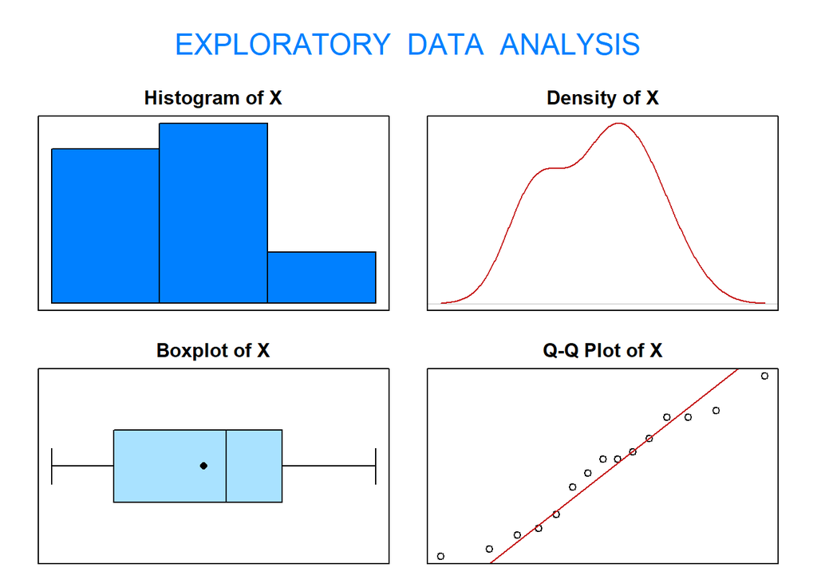

   ```
   ## Size (n)  Missing  Minimum   1st Qu     Mean   Median   TrMean   3rd Qu
   ##   15.000    0.000    1.000    1.500    2.220    2.400    2.220    2.850
   ##      Max    Stdev      Var  SE Mean   I.Q.R.    Range Kurtosis Skewness
   ##    3.600    0.800    0.640    0.207    1.350    2.600   -1.352   -0.052
   ## SW p-val
   ##    0.613
   ```

   ```r
   alpha1 <- 0.05
   X <- HUBBLE$team1
   Y <- HUBBLE$team2
   eda(X)
   ```

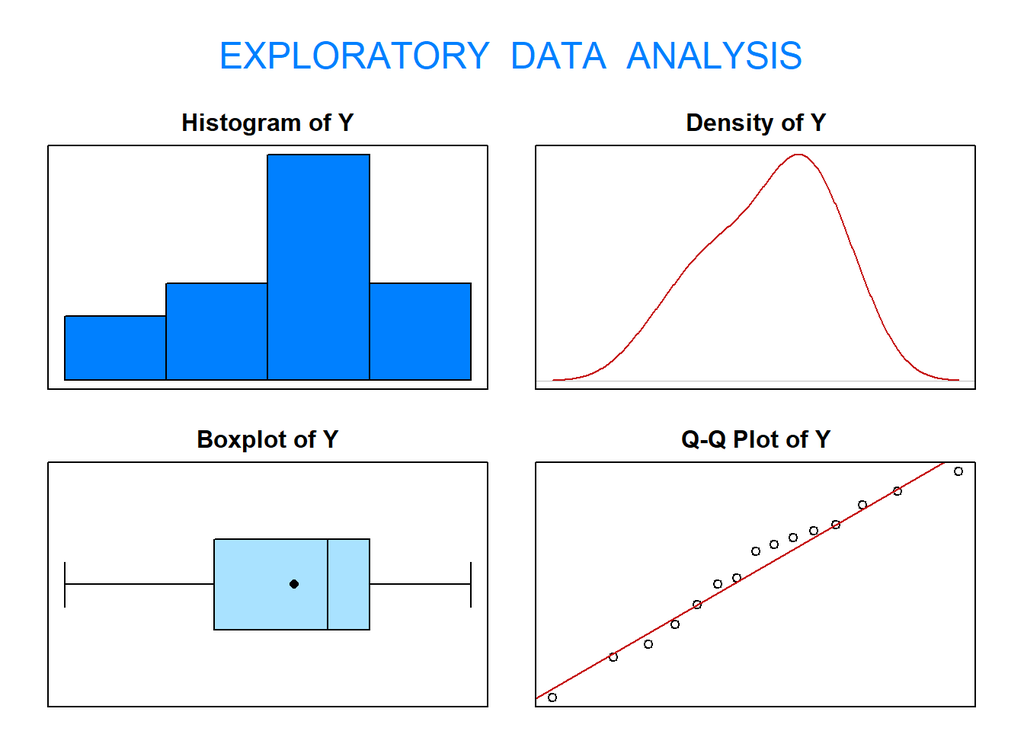

   ```
   ## Size (n)  Missing  Minimum   1st Qu     Mean   Median   TrMean   3rd Qu
   ##   15.000    0.000    0.400    1.650    2.320    2.600    2.320    2.950
   ##      Max    Stdev      Var  SE Mean   I.Q.R.    Range Kurtosis Skewness
   ##    3.800    0.981    0.963    0.253    1.300    3.400   -1.074   -0.350
   ## SW p-val
   ##    0.848
   ```

   ```r
   eda(Y)
   ```

   ```r
   print("pvalorx = 0.613, pvalory = 0.848, como pvalorx,pvalory > alpha")
   ```

   ```
   ## [1] "pvalorx = 0.613, pvalory = 0.848, como pvalorx,pvalory > alpha"
   ```

   ```r
   print("Ho: tiempos de equipo1/tiempos de equipo2 = 1 vs H1: tiempos de equipo1/tiempos de equipo2 > 1")
   ```

   ```
   ## [1] "Ho: tiempos de equipo1/tiempos de equipo2 = 1 vs H1: tiempos de equipo1/tiempos de equipo2 > 1"
   ```

   ```r
   var.test(x=X, y=Y, alternative="greater")
   ```

   ```
   ##
   ##  F test to compare two variances
   ##
   ## data:  X and Y
   ## F = 0.66479, num df = 14, denom df = 14, p-value = 0.7727
   ## alternative hypothesis: true ratio of variances is greater than 1
   ## 95 percent confidence interval:
   ##  0.2676575       Inf
   ## sample estimates:
   ## ratio of variances
   ##          0.6647879
   ```

   ```r
   pvalor1 <- 0.7727
   if(pvalor1 < alpha1) {
     print("Rechazo Ho, porque el ratio de varianzas es distinto a 1, signfica que hay un   equipo que realiza mejores tiempos que otro, nos quedamos con H1")
   } else {
     print("Acepto Ho porque el ratio de varianzas es igual a 1 eso significa que los dos   equipos completan la mision en tiempos aproximadamente iguales.")
     print("Por lo tanto, no fue un equipo mejor que el otro.")
   }
   ```

   ```
   ## [1] "Acepto Ho porque el ratio de varianzas es igual a 1 eso significa que los dos   equipos completan la mision en tiempos aproximadamente iguales."
   ## [1] "Por lo tanto, no fue un equipo mejor que el otro."
   ```

   ```r
   print("SEGUNDA PARTE: SI NO ES ASI, PODRIAN COMPLETAR LA MISION EN MENOS DE TRES DIAS?")
   ```

   ```
   ## [1] "SEGUNDA PARTE: SI NO ES ASI, PODRIAN COMPLETAR LA MISION EN MENOS DE TRES DIAS?"
   ```

   ```r
   print("X2: tiempo de el equipo 1 en 3 dias, Y2: tiempo de el equipo 2 en 3 dias")
   ```

   ```
   ## [1] "X2: tiempo de el equipo 1 en 3 dias, Y2: tiempo de el equipo 2 en 3 dias"
   ```

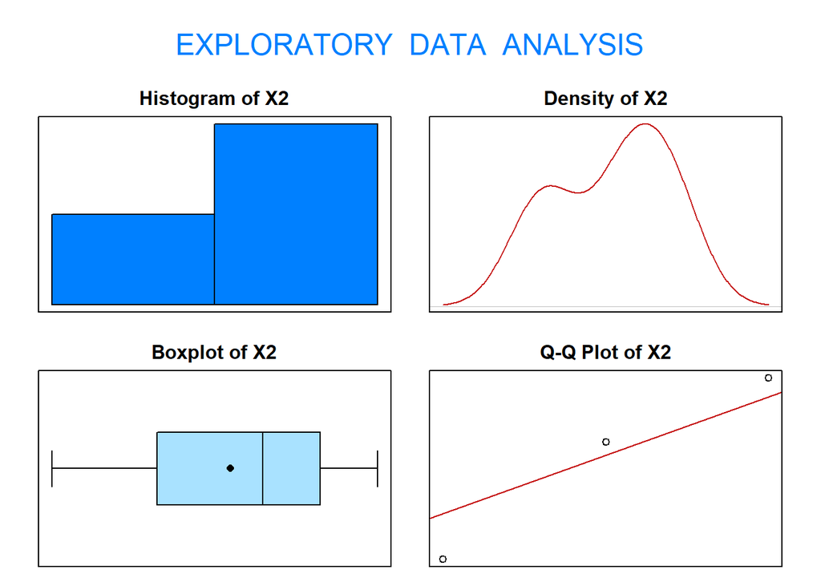

   ```
   ## Size (n)  Missing  Minimum   1st Qu     Mean   Median   TrMean   3rd Qu
   ##    3.000    0.000    1.300    1.850    2.233    2.400    2.233    2.700
   ##      Max    Stdev      Var  SE Mean   I.Q.R.    Range Kurtosis Skewness
   ##    3.000    0.862    0.743    0.498    0.850    1.700   -2.333   -0.186
   ## SW p-val
   ##    0.679
   ```

   ```r
   X2 <- c(HUBBLE$team1[1],HUBBLE$team1[2],HUBBLE$team1[3])
   Y2 <- c(HUBBLE$team2[1],HUBBLE$team2[2],HUBBLE$team2[3])
   nx2<-length(X2)
   ny2<-length(Y2)
   eda(X2)
   ```

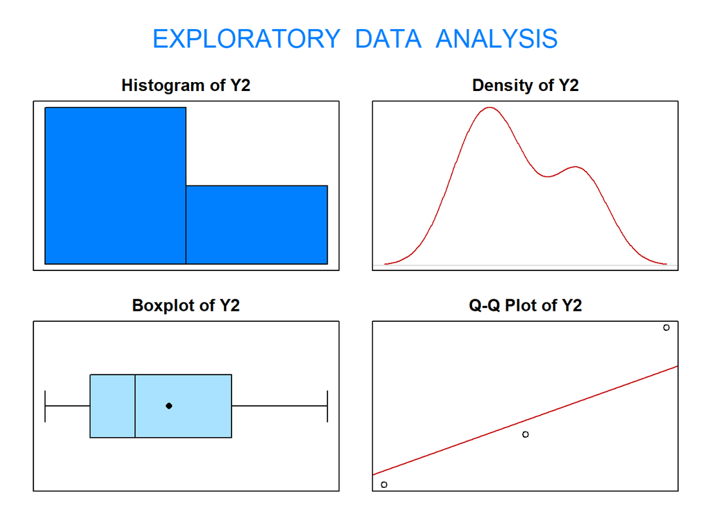

   ```
   ## Size (n)  Missing  Minimum   1st Qu     Mean   Median   TrMean   3rd Qu
   ##    3.000    0.000    1.000    1.400    2.100    1.800    2.100    2.650
   ##      Max    Stdev      Var  SE Mean   I.Q.R.    Range Kurtosis Skewness
   ##    3.500    1.277    1.630    0.737    1.250    2.500   -2.333    0.222
   ## SW p-val
   ##    0.609
   ```

   ```r
   eda(Y2)
   ```

   ```r
   print("pvalorx = 0.679,pvalory= 0.609 como pvalorx, pvalory > alpha")
   ```

   ```
   ## [1] "pvalorx = 0.679,pvalory= 0.609 como pvalorx, pvalory > alpha"
   ```

   ```r
   print("Ho: dias < 3 vs H1: dias >=3")
   ```

   ```
   ## [1] "Ho: dias < 3 vs H1: dias >=3"
   ```

   ```r
   var.test(x=X2, y=Y2, alternative="greater")
   ```

   ```
   ##
   ##  F test to compare two variances
   ##
   ## data:  X2 and Y2
   ## F = 0.45603, num df = 2, denom df = 2, p-value = 0.6868
   ## alternative hypothesis: true ratio of variances is greater than 1
   ## 95 percent confidence interval:
   ##  0.02400172        Inf
   ## sample estimates:
   ## ratio of variances
   ##          0.4560327
   ```

   ```r
   pvalor2 <- 0.6868
   if(pvalor2 >= alpha1) {
     print("No rechazo Ho, los dos equipos podran comletar la mision en menos de tres dias")
   } else {
     print("Rechazo Ho porque obviamente se cumple que tienen que utilizar mas de 3 dias.")
   }
   ```

   ```
   ## [1] "No rechazo Ho, los dos equipos podran comletar la mision en menos de tres dias"
   ```

# Problema 2

Una agencia de publicidad está interesada en apuntar al género apropiado para un nuevo yogurt bajo en grasas (“low-fat”). En una encuesta nacional, 825 de 1200 mujeres escogieron el yogur “low-fat” frente a un yogur normal y 512 de 1150 hombres escogieron el yogur “lof-fat” frente al normal. Dados estos resultados, debería enfocarse la publicidad en un género específico?. Realiza el test apropiado con $\alpha = 0.01$.

```r
print("Casos.favorablesh: numero de hombres que prefieren lowfat")
```

```
## [1] "Casos.favorablesh: numero de hombres que prefieren lowfat"
```

```r
print("Casos.favorablesm: numero de mujeres que prefieren lowfat")
```

```
## [1] "Casos.favorablesm: numero de mujeres que prefieren lowfat"
```

```r
Casos.favorablesm <- 825
nm <- 1200
Casos.favorablesh <- 512
nh <- 1150
alpha2 <- 0.01
print("Ho: casos.favorablesh - casos.favorablesm = 0,
      H1: casos.favorablesh - casos.favorablesm < 0")
```

```
## [1] "Ho: casos.favorablesh - casos.favorablesm = 0,\n      H1: casos.favorablesh - casos.favorablesm < 0"
```

```r
#si Ho ocurre es que la publicidad no deberia enficarse hacia ningun publico
#si H1 ocurre es que la publicidad deberia enfocarse hacia las mujeres
prop.test(x = c(Casos.favorablesh, Casos.favorablesm), n = c(nh, nm), correct=TRUE, alternative = "less")
```

```
##
##  2-sample test for equality of proportions with continuity correction
##
## data:  c(Casos.favorablesh, Casos.favorablesm) out of c(nh, nm)
## X-squared = 139.57, df = 1, p-value < 2.2e-16
## alternative hypothesis: less
## 95 percent confidence interval:
##  -1.0000000 -0.2087893
## sample estimates:
##    prop 1    prop 2
## 0.4452174 0.6875000
```

```r
pvalor3 <- 24.57*10^-8
if(pvalor3 < alpha2){
  print("Rechazamos Ho, la publicidad se deberia decantar por un publico mas femenino.")
} else {
  print("Aceptamos Ho, la publicidad no deberia decantarse por ningun publico.")
}
```

```
## [1] "Rechazamos Ho, la publicidad se deberia decantar por un publico mas femenino."
```

# Problema 3

Un fabricante de baterías de litio tiene dos plantas de producción. Una planta produce baterías con un una vida útil de 200 horas (facility A), mientras que la segunda planta produce baterías con una vida útil de 180 horas (facility B). Ambas plantas están tratando de reducir la varianza en el tiempo de vida de sus productos y los datos se recogen en el data frame `BATTERY`.

¿La variabilidad en el tiempo de vida es equivalente para ambas plantas o la evidencia sugiere que la planta que produce baterías de 180 horas tiene menos variabilidad que la que produce baterías de 200 horas? Utiliza $\alpha = 0.05$ para realizar el test de hipótesis apropiado.

```r
library(PASWR2)
head(BATTERY)
```

```
##   lifetime facility
## 1 203.2983        A
## 2 199.9072        A
## 3 200.5710        A
## 4 204.0056        A
## 5 202.1917        A
## 6 200.1686        A
```

```r
alpha3 <- 0.05
print("A: planta que produce baterias con un lifetime de 200h")
```

```
## [1] "A: planta que produce baterias con un lifetime de 200h"
```

```r
print("B: planta que produce baterias con un lifetime de 180h")
```

```
## [1] "B: planta que produce baterias con un lifetime de 180h"
```

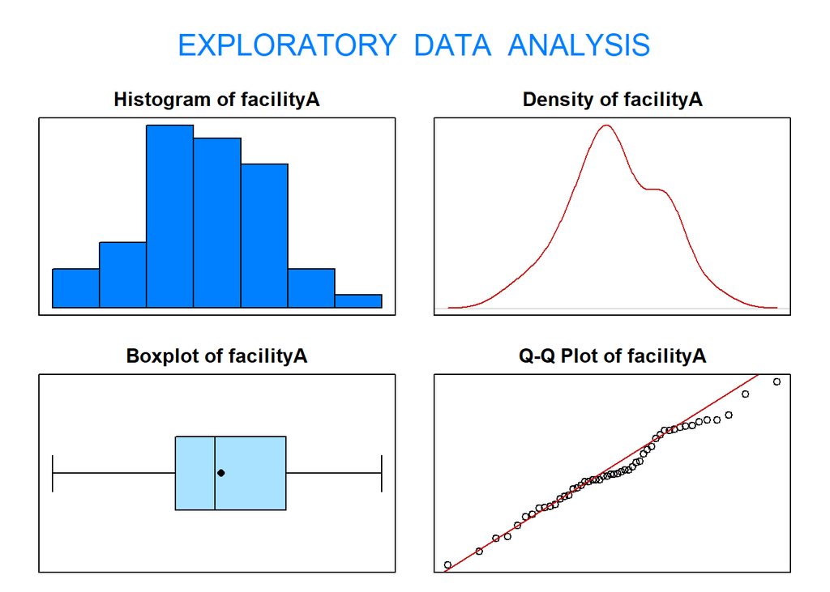

```
## Size (n)  Missing  Minimum   1st Qu     Mean   Median   TrMean   3rd Qu
##   50.000    0.000  194.096  198.793  200.509  200.284  200.520  202.913
##      Max    Stdev      Var  SE Mean   I.Q.R.    Range Kurtosis Skewness
##  206.625    2.746    7.539    0.388    4.120   12.529   -0.428   -0.061
## SW p-val
##    0.763
```

```r
facilityA <- BATTERY$lifetime[BATTERY$facility=="A"]
facilityB <- BATTERY$lifetime[BATTERY$facility=="B"]
eda(facilityA)
```

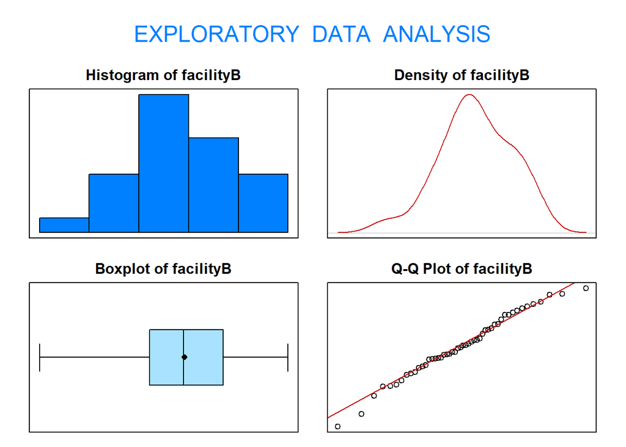

```
## Size (n)  Missing  Minimum   1st Qu     Mean   Median   TrMean   3rd Qu
##   50.000    0.000  174.221  178.458  179.681  179.633  179.739  181.132
##      Max    Stdev      Var  SE Mean   I.Q.R.    Range Kurtosis Skewness
##  183.571    2.085    4.347    0.295    2.674    9.350   -0.256   -0.268
## SW p-val
##    0.726
```

```r
eda(facilityB)
```

```r
print("pvalora=0.763, pvalorb=0.726 > alpha= 0.05")
```

```
## [1] "pvalora=0.763, pvalorb=0.726 > alpha= 0.05"
```

```r
print("Ho: vara/varb = 1 vs H1: vara/varb > 1")
```

```
## [1] "Ho: vara/varb = 1 vs H1: vara/varb > 1"
```

```r
var.test(x=facilityA, y=facilityB, alternative="greater")
```

```
##
##  F test to compare two variances
##
## data:  facilityA and facilityB
## F = 1.7343, num df = 49, denom df = 49, p-value = 0.02836
## alternative hypothesis: true ratio of variances is greater than 1
## 95 percent confidence interval:
##  1.079031      Inf
## sample estimates:
## ratio of variances
##           1.734314
```

```r
pvalor4 <- 0.02836
if(pvalor4 < alpha3){
  print("Rechazamos Ho, ya que el ratio de las varianzas será mayor que uno, es decir, nuestra hipotesis alternativa será cierta. Conclusion, la variabilidad de la planta A será mayor que la variabilidad de la planta B, es decir, la variabilidad de la planta de lifetime 200h será mayor que la variabilidad de la planta de lifetime de 180h.")
} else {
  print("Aceptamos Ho, ya que el ratio de las varianzas será uno, es decir, nuestra hipotesis nula será cierta. Conclusion, la variabilidad de la planta A será igual que la variabilidad de la planta B, es decir, la variabilidad de la planta de lifetime 200h será igual que la variabilidad de la planta de lifetime de 180h.")
}
```

[output not shown]